# Lecture 9 – Support Vector Machines

2016-04-26

## Introduction

- Outcome variable: \(Y \in \{-1,+1\}\)
- Generalization to multi-valued outcomes is straight forward.
- Basic Idea (for classification): Separating the space of features by hyperplanes into different regressions so that the dependent variable / outcome is separated.
- *Seperating* hyperplanes
- Graph: cf white board
- In this lecture we focus only on the basic idea.

## Digression: Hyperplanes

- In a p-dimensional space a *hyperplane* is a flat affine subspace of dimension p-1-
- Example 1: In \(p=2\) a hyperplane is a line.
- Example 2: In \(p=3\) a hyperplane is a plane.
- A hyperplane is a \(p\)-dimensional space is defined by \[\beta_0 + \beta_1 X_1 + \ldots \beta_p X_p = 0\].
- If \(\beta_0 + \beta_1 X_1 + \ldots \beta_p X_p <0\) than \(X=(X_1,\ldots,X_p)\) lies on one side of the hyperplane.
- If \(\beta_0 + \beta_1 X_1 + \ldots \beta_p X_p >0\) than \(X\) lies on the other side of the hyperplane.
- Hence: Separation of the space into two parts.
- \(f(x)=\beta_0 + \beta_1 x_1 + \ldots \beta_p x_p\) gives the signed distance from a point \(x\) to the hyperplane defined by \(f(x)=0\)

## Support Vector Classifier

- Training data: \((x_1, y_1), \ldots, (x_n,y_n)\), \(x_i \in \mathbb{R}^p\) and \(y_i \in \{-1, +1\}\)
- Definition hyperplane: \(\{x: f(x)=x^T \beta + \beta_0=0 \}\) (\(\beta\) unit vector with \(\|\beta\|=1\))
- Classification rule: \(G(x)=sign[x^T \beta + \beta_0]\)

## Support Vector Classifier: Separable Case

- Separable means: \(y_i f(x_i)>0 \forall i\) for a plane \(f(x)\)
- Find the hyperplane that creates the biggest margin between the classes for \(-1\) and \(+1\).
- Optimization problem: \(\max_{\beta, \beta_0, \|\beta\|=1} M\) subject to\[ y_i(x_i^T \beta + \beta_0) \geq M, i=1,\ldots,n\]
- Equivalent formulation: \(\min_{\beta, \beta_0} \| \beta \|\) subject to\[ y_i(x_i^T \beta + \beta_0) \geq 1, i=1,\ldots,n\]

## Support Vector Classifiers: Non-separable Case

- Now: classes overlap in the feature space.
- Still maximize \(M\), but allow for some points to be on the wrong side of the margin.
- Slack variables \(\xi=(\xi_1, \ldots, x_n)\)
- Modification of the constraints: \(y_i(x_i^T \beta + \beta_0) \geq M - \xi_i\) or\(y_i(x_i^T \beta + \beta0 \geq M(1 - \xi_i)\)
- \(\forall \xi \geq 0, \sum_{i=1}^n \xi_i \leq constant\)
- Interpretation: overlap in actual distance from the margin vs overlap in relative distance.
- Focus on the second case (b/c convex optimization problem)

## Support Vector Classifiers: Non-separable Case

- \(\xi_i\) proportional amount by which the prediction \(f(x_i)\) is on the wrong side of the margin.
- Missclassification occurs, if \(\xi_i > 1\)
- Bounding \(\sum \xi_i\) at value \(K\), bounds the number of training missclassifications at \(K\).
- Equivalent formulation of the problem: \(\min \| \beta \|\) subject to\[ y_i(x_i^T \beta + \beta_0) \geq 1 - \xi_i \forall i, \xi_i \geq 0, \sum \xi_i \leq K\]

## Support Vector Machines

- Up to now: linear boundaries in the feature space.
- Flexibility by enlarging the feature space using basis expansions (e.g. polynomials, splines)
- Better training-class separation and nonlinear boundaries in the original space.
- Selection of basis functions \(h_m(x), m=1,\ldots, M\) and fit of SV classifier using the input features \(h(x_i)=(h_1(x_i), \ldots, h_M(x_i))\).
- Nonlinear function \(\hat{f}(x)= h(x)^T \hat{\beta} + \hat{\beta_0}\)
- Classifier: \(\hat{G}=sign(\hat{f}(x))\)

## Support Vector Machines

- SVM use a very large space of basis functions leading to computational problems.
- Problem of overfitting.
- SVM technology takes care of both problems.

## Support Vector Machines

- (omitting technical details)
- Solution of the optimization problem involve \(h(x)\) only through inner products.
- Knowledge of the kernel functions \(K(x,x')= \langle h(x), h(x') \rangle\) is sufficient.
- Examples:+ \(d\)th degree polynomial: \(K(x,x')= (1+ \langle x,x' \rangle)^d\)+ Radial basis: \(K(x,x')=\exp(-\gamma \|x-x'\|^2)\)

## Support Vector Machines

### Example

- Consider two-dimensional space \((X_1,X_2)\) and polynomial kernel of degree 2.
- \(K(X,X')=1+2X_1 X_1' + 2 X_2 X_2' + (X_1 X_1')^2 + (X_2 X_2')^2 + 2 X_1 X_1' X_2 X_2'\)
- Then \(M=6\) and \(h_1(X)=1, h_2(X)=\sqrt(2) X_1, \ldots\). Then \(K(X,X')=\langle h(X), h(X') \rangle\)

## SVM as a Penalization Method

- With \(f(x)=h(x)^T \beta + \beta_0\), we consider the optimization problem:\[ \min_{\beta_0, \beta} \sum_{i=1}^n [ 1- y_i f(x_i)]_{+} + \frac{\lambda}{2} \| \beta \|^2\]
- loss + penalty
- Hinge loss function: \(L(y,f)=[1- yf]_{+}\)
- Solution to the above optimization problem (with \(\lambda = 1/C\)) is the same as for the SVM problem.
- (\(C\) is a Cost parameter related to \(K\))

## SVM

### An Illustration

We use the library *e1071* (alternative *LiblineaR* for very large linear problems)

```r
library(e1071)
```

First, we generate data we would like to classify

```r
set.seed(12345)
x = matrix(rnorm(200*2), ncol=2)
x[1:100,] = x[1:100,] + 2
x[101:150,] = x[101:150,] - 2
y = c(rep(1,150), rep(2,50))
dat = data.frame(x=x, y=as.factor(y))
```

## SVM

### An Illustration

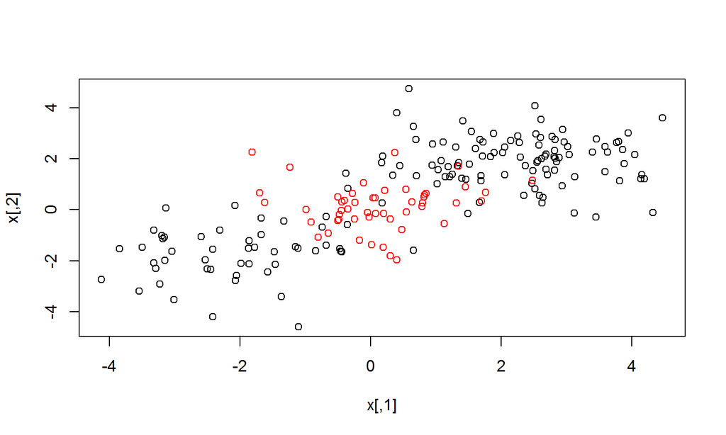

```r
plot(x, col=y)
```

## SVM

### An Illustration

Next, we split the data into training and testing sample

```r
train = sample(200,100)
```

Then we fit a SVM with radial basis and plot the result

```r
svmfit = svm(y~., data=dat[train,], kernel="radial", gamma=1, cost=1)
# summary(smvfit)
```

## SVM

### An Illustration

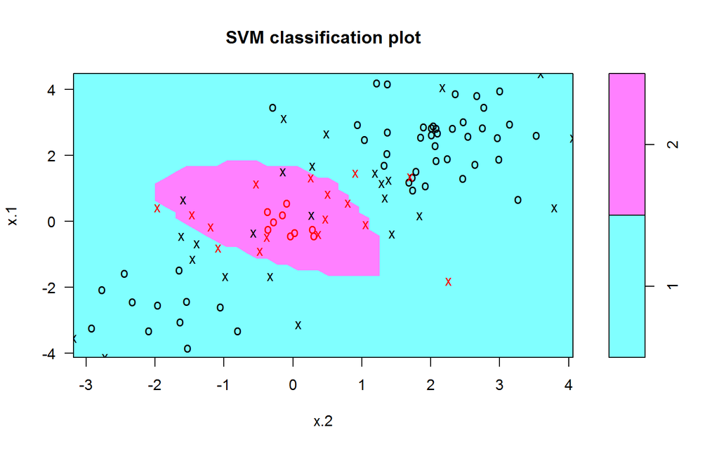

```r
plot(svmfit, dat[train,])
```

## SVM

### An Illustration

We can now increase the cost parameter to reduce the training errors

```r
svmfit = svm(y~., data=dat[train,], kernel="radial", gamma=1, cost=1e5)
#plot(svmfit, dat[train,])
# summary(smvfit)
```

## SVM

### An Illustration

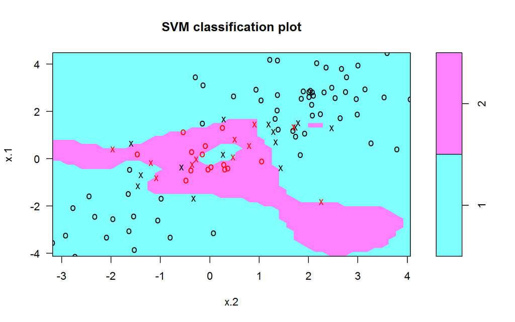

```r
plot(svmfit, dat[train,])
```

## SVM

### An Illustration

Selection of the cost parameter and \(\gamma\) by CV

```r
tune.out=tune(svm, y~., data=dat[train,], kernel="radial", ranges=list(cost=c(0.1,1,10,100,1000), gamma=c(0.5,1,2,3,4)))
#summary(tune.out)
```

## SVM

### An Illustration

Finally, we test it on the testing data

```r
table(true=dat[-train,"y"], pred=predict(tune.out$best.model, newdata=dat[-train,]))
```

```
##     pred
## true  1  2
##    1 70  5
##    2  4 21
```